# F0

Jesse Leigh Patsolic

```r
input <- "~/neurodata/synaptome-stats/data/Kristina15Datasets/testSynaptograms.h5"
token <- "kristina15"
output<- "testF0"
bf    <- 5

suppressPackageStartupMessages(require(rhdf5))
suppressPackageStartupMessages(require(meda))
require(gridExtra)
require(foreach)

cnames <- h5read(input, name = "Channels")
abcnames <- abbreviate(gsub("_", "", cnames), minlength = 3)
abtab <- rbind(ch_names = cnames, abb = abcnames)
dat <- h5read(input, name = token)

dimnames(dat) <- list(1:dim(dat)[1], cnames, NULL, NULL, NULL)
datO <- dat
loc <- h5read(input, name = "Locations")
H5close()

## Type for kristina data full only!!!
type <- c("in", "ex", "in", "ot",
          "in", "ex", "ot", "in",
          "ot", "ex", "ex", "ex",
          "ex", "in", "in", "ex",
          "ex", "ex", "ot", "in",
          "ex", "ex", "in")

tab <- table(type)
ctype <- data.frame(cnames, type)
ord <- order(type)

inpal <- colorpanel(255,"black", "red")
expal <- colorpanel(255, "black", "green")
otpal <- colorpanel(255, "black", "blue")

datS <- datO
## Normalize across channels
for(j in 1:dim(dat)[2]){
    a1 <- (dat[,j,,,])
    if(!all(a1 == 0)){
      a2 <- scale(a1, center = TRUE, scale = TRUE)
      #a2 <- (a1 - min(a1))/(max(a1) - min(a1))
      #a3 <- log10(a1 + 1)
      dat[,j,,,] <- a2
    }
  }

for(j in 1:dim(datS)[2]){
    a1 <- (datS[,j,,,])
    if(!all(a1 == 0)){
      #a2 <- scale(a1, center = TRUE, scale = TRUE)
      a2 <- (a1 - min(a1))/(max(a1) - min(a1))
      #a3 <- log10(a1 + 1)
      datS[,j,,,] <- a2
    }
  }
```

# [Full plots here](http://cis.jhu.edu/~jesse/fotd/2017/05/15/)

## F0 as number on side

Here the F0 featrue is calculated from the z-scored data and printed as a number on teh right hand side of the plot.

```r
## Calculate feature F0
F0 <-
  foreach(j = 1:dim(dat)[1]) %:%
  foreach(i = 1:dim(dat)[2]) %do% {
      f0 <- sum(dat[j,i,,,])
}

names(F0) <- 1:length(F0)
for(i in 1:length(F0)){
  names(F0[[i]]) <- cnames
}


rr <- foreach(l = 1:dim(dat)[1]) %do% {
  r <- dat[l,,,,]
  mr <- melt(r)
  names(mr) <- c("ch", "x", "y", "z", "value")
  mr$z <- mr$z - (max(mr$z) +1)/2

  F0z <- Reduce('rbind',
           lapply(names(F0[[l]]),
             function(n){
             Fz <- mr[mr$ch == n,]
             #Fz$z <- as.numeric(max(mr$z)+1)
             Fz$F0 <- round(as.numeric(F0[[l]][n]),4)
             Fz
             }))

  #mr <- rbind(mr, F0z)
  #ch <- mr$ch
  #mr$type <- ctype$type[ch]
  #mr$ch <- abcnames[ch]
  #mr
  ch <- F0z$ch
  F0z$type <- ctype$type[ch]
  F0z$ch <- abcnames[ch]
  F0z
}


names(rr) <- 1:length(rr)


th <- theme(axis.text = element_blank(), axis.ticks = element_blank(),
            axis.title.y = element_blank(), axis.title.x = element_blank(),
            legend.position="bottom", legend.key.size = unit(2,'lines'),
            panel.spacing = unit(0, "lines"))

mmex <- min(sapply(rr, function(am){ min(am[am$type == "ex",]$value) }))
MMex <- max(sapply(rr, function(am){ max(am[am$type == "ex",]$value) }))
mmin <- min(sapply(rr, function(am){ min(am[am$type == "in",]$value) }))
MMin <- max(sapply(rr, function(am){ max(am[am$type == "in",]$value) }))
mmot <- min(sapply(rr, function(am){ min(am[am$type == "ot",]$value) }))
MMot <- max(sapply(rr, function(am){ max(am[am$type == "ot",]$value) }))

ggp <- list()
for(k in 1:length(rr)){
  mr <- rr[[k]]
  pex <-
  ggplot(mr[mr$type == "ex",],
    aes(x,y, group = factor(type), fill = value)) +
    geom_raster() +
    scale_y_reverse() +
    facet_grid(ch + F0 ~ z, labeller = label_both) +
    scale_fill_gradient(low = "black", high = "green", limits = c(mmex,MMex)) + th

  pin <-
  ggplot(mr[mr$type == "in",],
    aes(x,y, group = factor(type), fill = value)) +
    geom_raster() +
    scale_y_reverse() +
    facet_grid(ch + F0 ~ z, labeller = label_both) +
    scale_fill_gradient(low = "black", high = "red", limits = c(mmin,MMin)) + th

  pot <-
    ggplot(mr[mr$type == "ot",],
    aes(x,y, group = factor(type), fill = value)) +
    geom_raster() +
    scale_y_reverse() +
    facet_grid(ch + F0 ~ z, labeller = label_both) +
    scale_fill_gradient(low = "black", high = "blue", limits = c(mmot,MMot)) + th
  #

  lay <- rbind(matrix(1,table(type)['ex'],1),
        matrix(2,table(type)['in'],1),
        matrix(3,table(type)['ot'],1))

  xyzloc = c(x = loc[k,1],
          y = loc[k,2],
          z = loc[k,3])

  p <- arrangeGrob(pex, pin, pot, layout_matrix = lay)

  ggp[[k]] <- list(xyzloc=xyzloc, p=p, pex=pex, pin=pin, pot=pot)
}

save(ggp, file = "F0num.RData")

mapply(function(grob,locs){
  outName <- paste0("num",token,
               paste0(c("x", "y", "z"),locs, collapse="_"),
               ".png")
  png(outName,
      height = sum(tab)*1.5, width = dim(dat)[5]*1.5,
      units = "in", res = 300)
  plot(grob)
  dev.off()},
  lapply(ggp, '[[', 2), lapply(ggp, '[[', 1))
```

```
## quartz_off_screen quartz_off_screen quartz_off_screen quartz_off_screen
##                 2                 2                 2                 2
```

## F0 as number on side

```
##          CR12ndA    GluR22ndA    PV1stA    VAChT4thA    GABARa14thA
## ch_names "CR1_2ndA" "GluR2_2ndA" "PV_1stA" "VAChT_4thA" "GABARa1_4thA"
## abb      "CR1"      "GR2"        "PV1"     "VAC"        "GABAR"
##          VGluT22ndA    tubulin8thA    VGluT31stA    TH5thA
## ch_names "VGluT2_2ndA" "tubulin_8thA" "VGluT3_1stA" "TH_5thA"
## abb      "VGT2"        "t8A"          "VGT3"        "TH5"
##          VGluT13rdA    NR2B9thA    VGluT18thA    synapsinR7thA
## ch_names "VGluT1_3rdA" "NR2B_9thA" "VGluT1_8thA" "synapsinR_7thA"
## abb      "VGT13"       "NR2"       "VGT18"       "sR7"
##          GAD6thA    VGAT5thA    Synpod3rdA    synapsinGP5thA    psd8thA
## ch_names "GAD_6thA" "VGAT_5thA" "Synpod_3rdA" "synapsinGP_5thA" "psd_8thA"
## abb      "GAD"      "VGA"       "S3A"         "sGP"             "p8A"
##          dapi1stA    GABABR13rdA    NMDAR16thA    NOS9thA
## ch_names "dapi_1stA" "GABABR1_3rdA" "NMDAR1_6thA" "NOS_9thA"
## abb      "d1A"       "GABAB"        "NMD"         "NOS"
##          gephyrin1stA
## ch_names "gephyrin_1stA"
## abb      "g1A"
```

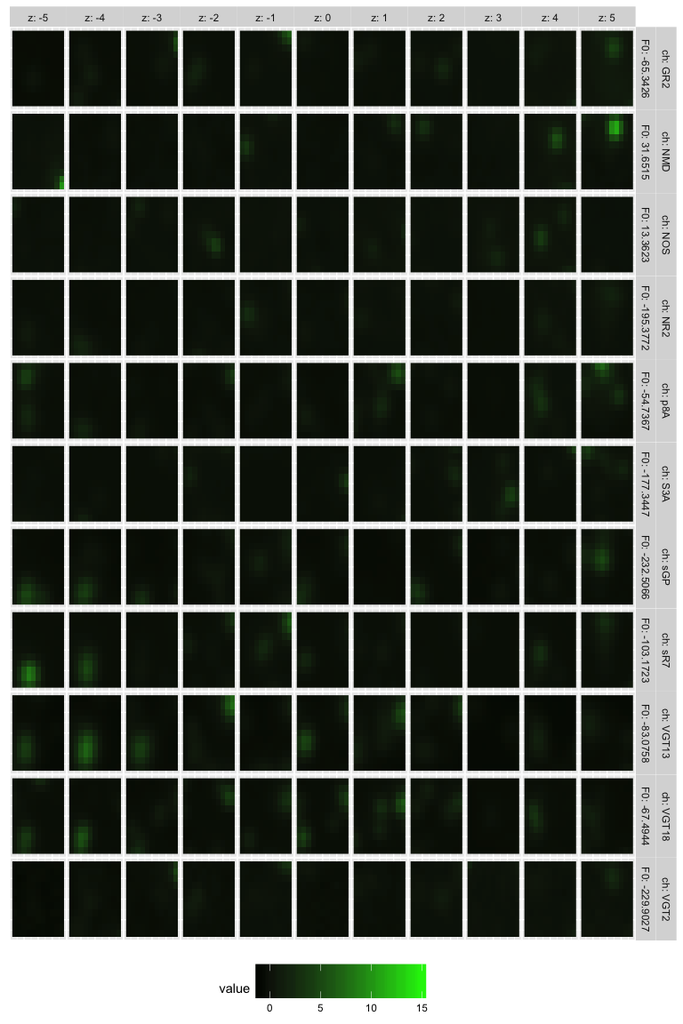

```r
print(abtab)
plot(ggp[[1]]$pex)
```

## F0 as a matrix :X:

Here I compute F0 as above and join a matrix to the z = 6 slot that is full of the same F0 value. The F0 value is much larger than the pixel values and overshadows the colorbar.

```r
## Calculate feature F0
F0 <-
  foreach(j = 1:dim(dat)[1]) %:%
  foreach(i = 1:dim(dat)[2]) %do% {
      #f0 <- matrix(sum(dat[j,i,,,]), 2*bf +1, 2*bf +1)
      f0 <- sum(dat[j,i,,,])
}

names(F0) <- 1:length(F0)
for(i in 1:length(F0)){
  names(F0[[i]]) <- cnames
}

rr <- foreach(l = 1:dim(dat)[1]) %do% {
  r <- dat[l,,,,]
  mr <- melt(r)
  names(mr) <- c("ch", "x", "y", "z", "value")
  mr$z <- mr$z - (max(mr$z) +1)/2
  mz <- min(mr$z)
  Mz <- max(mr$z)

  F0z <- Reduce('rbind',
           lapply(names(F0[[l]]),
             function(n){
             Fz <- mr[mr$ch == n,]
             Fz$z <- "F0" #as.numeric(max(mr$z)+1)
             Fz$value <- as.numeric(F0[[l]][n])
             Fz
             }))

  mr <- rbind(mr, F0z)
  ch <- mr$ch
  mr$type <- ctype$type[ch]
  mr$ch <- as.factor(abcnames[ch])
  mr$z <- factor(mr$z, levels = c(as.character(mz:Mz), "F0"))
  mr
  #ch <- F0z$ch
  #F0z$type <- ctype$type[ch]
  #F0z$ch <- abcnames[ch]
  #F0z
}


names(rr) <- 1:length(rr)


th <- theme(axis.text = element_blank(), axis.ticks = element_blank(),
            axis.title.y = element_blank(), axis.title.x = element_blank(),
            legend.position="bottom", legend.key.size = unit(2,'lines'),
            panel.spacing = unit(0, "lines"))

mmex <- min(sapply(rr, function(am){ min(am[am$type == "ex",]$value) }))
MMex <- max(sapply(rr, function(am){ max(am[am$type == "ex",]$value) }))
mmin <- min(sapply(rr, function(am){ min(am[am$type == "in",]$value) }))
MMin <- max(sapply(rr, function(am){ max(am[am$type == "in",]$value) }))
mmot <- min(sapply(rr, function(am){ min(am[am$type == "ot",]$value) }))
MMot <- max(sapply(rr, function(am){ max(am[am$type == "ot",]$value) }))

ggpmat <- list()
for(k in 1:length(rr)){
  mr <- rr[[k]]

  pex <-
  ggplot(mr[mr$type == "ex",],
    aes(x,y, group = factor(type), fill = value)) +
    geom_raster() +
    scale_y_reverse() +
    facet_grid(ch ~ z, labeller = label_both) +
    scale_fill_gradient(low = "black", high = "green", limits = c(mmex,MMex)) + th

  pin <-
  ggplot(mr[mr$type == "in",],
    aes(x,y, group = factor(type), fill = value)) +
    geom_raster() +
    scale_y_reverse() +
    facet_grid(ch ~ z, labeller = label_both) +
    scale_fill_gradient(low = "black", high = "red", limits = c(mmin,MMin)) + th

  pot <-
    ggplot(mr[mr$type == "ot",],
    aes(x,y, group = factor(type), fill = value)) +
    geom_raster() +
    scale_y_reverse() +
    facet_grid(ch ~ z, labeller = label_both) +
    scale_fill_gradient(low = "black", high = "blue", limits = c(mmot,MMot)) + th
  #

  lay <- rbind(matrix(1,table(type)['ex'],1),
        matrix(2,table(type)['in'],1), matrix(3,table(type)['ot'],1))

  xyzloc = c(x = loc[k,1],
          y = loc[k,2],
          z = loc[k,3])

  p <- arrangeGrob(pex, pin, pot, layout_matrix = lay)

  ggpmat[[k]] <- list(xyzloc=xyzloc, p=p, pex=pex, pin=pin, pot=pot)
}

save(ggpmat, file = "F0matrix.RData")

mapply(function(grob,locs){
  outName <- paste0("matrix",token,
               paste0(c("x", "y", "z"),locs, collapse="_"),
               ".png")
  png(outName,
      height = sum(tab)*1.5, width = dim(dat)[5]*1.5,
      units = "in", res = 300)
  plot(grob)
  dev.off()},
  lapply(ggpmat, '[[', 2), lapply(ggpmat, '[[', 1))
```

```
## quartz_off_screen quartz_off_screen quartz_off_screen quartz_off_screen
##                 2                 2                 2                 2
```

## F0 as matrix

```
##          CR12ndA    GluR22ndA    PV1stA    VAChT4thA    GABARa14thA
## ch_names "CR1_2ndA" "GluR2_2ndA" "PV_1stA" "VAChT_4thA" "GABARa1_4thA"
## abb      "CR1"      "GR2"        "PV1"     "VAC"        "GABAR"
##          VGluT22ndA    tubulin8thA    VGluT31stA    TH5thA
## ch_names "VGluT2_2ndA" "tubulin_8thA" "VGluT3_1stA" "TH_5thA"
## abb      "VGT2"        "t8A"          "VGT3"        "TH5"
##          VGluT13rdA    NR2B9thA    VGluT18thA    synapsinR7thA
## ch_names "VGluT1_3rdA" "NR2B_9thA" "VGluT1_8thA" "synapsinR_7thA"
## abb      "VGT13"       "NR2"       "VGT18"       "sR7"
##          GAD6thA    VGAT5thA    Synpod3rdA    synapsinGP5thA    psd8thA
## ch_names "GAD_6thA" "VGAT_5thA" "Synpod_3rdA" "synapsinGP_5thA" "psd_8thA"
## abb      "GAD"      "VGA"       "S3A"         "sGP"             "p8A"
##          dapi1stA    GABABR13rdA    NMDAR16thA    NOS9thA
## ch_names "dapi_1stA" "GABABR1_3rdA" "NMDAR1_6thA" "NOS_9thA"
## abb      "d1A"       "GABAB"        "NMD"         "NOS"
##          gephyrin1stA
## ch_names "gephyrin_1stA"
## abb      "g1A"
```

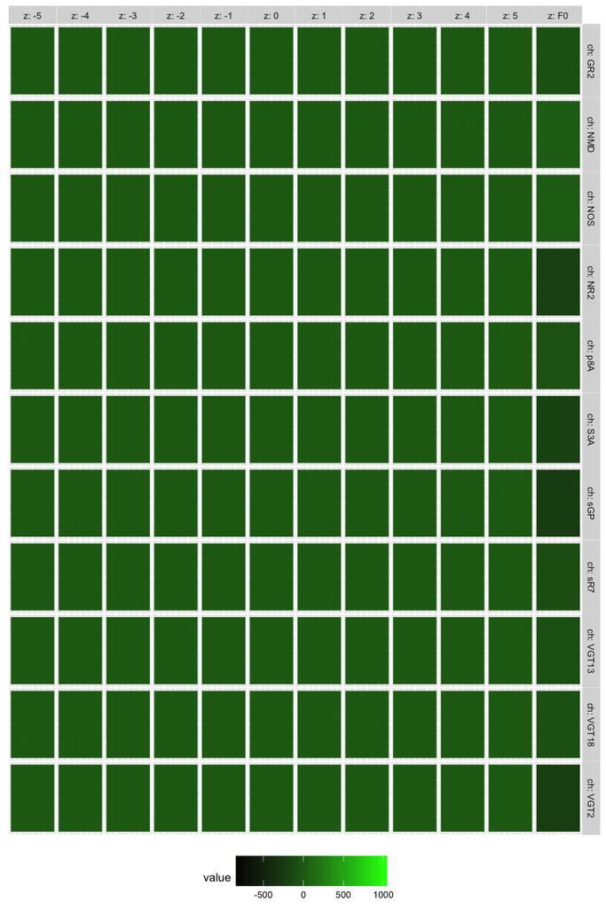

```r
print(abtab)
plot(ggpmat[[1]]$pex)
```

## F0 averaged :X:

Here I compute F0 as above and average it by the number of pixels = 1331 in each cube and add it as a matrix same as above.

Because most of the pixels values are small, this doesn’t seem to be visually helpful either.

```r
## Calculate feature F0
F0 <-
  foreach(j = 1:dim(dat)[1]) %:%
  foreach(i = 1:dim(dat)[2]) %do% {
      #f0 <- matrix(sum(dat[j,i,,,]), 2*bf +1, 2*bf +1)
      f0 <- sum(dat[j,i,,,])/1331
}

names(F0) <- 1:length(F0)
for(i in 1:length(F0)){
  names(F0[[i]]) <- cnames
}

rr <- foreach(l = 1:dim(dat)[1]) %do% {
  r <- dat[l,,,,]
  mr <- melt(r)
  names(mr) <- c("ch", "x", "y", "z", "value")
  mr$z <- mr$z - (max(mr$z) +1)/2

  F0z <- Reduce('rbind',
           lapply(names(F0[[l]]),
             function(n){
             Fz <- mr[mr$ch == n,]
             Fz$z <- "F0"#as.numeric(max(mr$z)+1)
             Fz$value <- as.numeric(F0[[l]][n])
             Fz
             }))

  mr <- rbind(mr, F0z)
  ch <- mr$ch
  mr$type <- ctype$type[ch]
  mr$ch <- as.factor(abcnames[ch])
  mr
  #ch <- F0z$ch
  #F0z$type <- ctype$type[ch]
  #F0z$ch <- abcnames[ch]
  #F0z
}


names(rr) <- 1:length(rr)


th <- theme(axis.text = element_blank(), axis.ticks = element_blank(),
            axis.title.y = element_blank(), axis.title.x = element_blank(),
            legend.position="bottom", legend.key.size = unit(2,'lines'),
            panel.spacing = unit(0, "lines"))

mmex <- min(sapply(rr, function(am){ min(am[am$type == "ex",]$value) }))
MMex <- max(sapply(rr, function(am){ max(am[am$type == "ex",]$value) }))
mmin <- min(sapply(rr, function(am){ min(am[am$type == "in",]$value) }))
MMin <- max(sapply(rr, function(am){ max(am[am$type == "in",]$value) }))
mmot <- min(sapply(rr, function(am){ min(am[am$type == "ot",]$value) }))
MMot <- max(sapply(rr, function(am){ max(am[am$type == "ot",]$value) }))

ggpavgmat <- list()
for(k in 1:length(rr)){
  mr <- rr[[k]]
  pex <-
  ggplot(mr[mr$type == "ex",],
    aes(x,y, group = factor(type), fill = value)) +
    geom_raster() +
    scale_y_reverse() +
    facet_grid(ch ~ z, labeller = label_both) +
    scale_fill_gradient(low = "black", high = "green", limits = c(mmex,MMex)) + th

  pin <-
  ggplot(mr[mr$type == "in",],
    aes(x,y, group = factor(type), fill = value)) +
    geom_raster() +
    scale_y_reverse() +
    facet_grid(ch ~ z, labeller = label_both) +
    scale_fill_gradient(low = "black", high = "red", limits = c(mmin,MMin)) + th

  pot <-
    ggplot(mr[mr$type == "ot",],
    aes(x,y, group = factor(type), fill = value)) +
    geom_raster() +
    scale_y_reverse() +
    facet_grid(ch ~ z, labeller = label_both) +
    scale_fill_gradient(low = "black", high = "blue", limits = c(mmot,MMot)) + th
  #

  lay <- rbind(matrix(1,table(type)['ex'],1),
        matrix(2,table(type)['in'],1),
        matrix(3,table(type)['ot'],1))

  xyzloc = c(x = loc[k,1],
          y = loc[k,2],
          z = loc[k,3])

  p <- arrangeGrob(pex, pin, pot, layout_matrix = lay)

  ggpavgmat[[k]] <- list(xyzloc=xyzloc, p=p, pex=pex, pin=pin, pot=pot)
}

save(ggpavgmat, file = "F0avgmatrix.RData")

mapply(function(grob,locs){
  outName <- paste0("avgmatrix",token,
               paste0(c("x", "y", "z"),locs, collapse="_"),
               ".png")
  png(outName,
      height = sum(tab)*1.5, width = dim(dat)[5]*1.5,
      units = "in", res = 300)
  plot(grob)
  dev.off()},
  lapply(ggpavgmat, '[[', 2), lapply(ggpavgmat, '[[', 1))
```

```
## quartz_off_screen quartz_off_screen quartz_off_screen quartz_off_screen
##                 2                 2                 2                 2
```

## F0 matrix divided by 1331 = 11^3

```
##          CR12ndA    GluR22ndA    PV1stA    VAChT4thA    GABARa14thA
## ch_names "CR1_2ndA" "GluR2_2ndA" "PV_1stA" "VAChT_4thA" "GABARa1_4thA"
## abb      "CR1"      "GR2"        "PV1"     "VAC"        "GABAR"
##          VGluT22ndA    tubulin8thA    VGluT31stA    TH5thA
## ch_names "VGluT2_2ndA" "tubulin_8thA" "VGluT3_1stA" "TH_5thA"
## abb      "VGT2"        "t8A"          "VGT3"        "TH5"
##          VGluT13rdA    NR2B9thA    VGluT18thA    synapsinR7thA
## ch_names "VGluT1_3rdA" "NR2B_9thA" "VGluT1_8thA" "synapsinR_7thA"
## abb      "VGT13"       "NR2"       "VGT18"       "sR7"
##          GAD6thA    VGAT5thA    Synpod3rdA    synapsinGP5thA    psd8thA
## ch_names "GAD_6thA" "VGAT_5thA" "Synpod_3rdA" "synapsinGP_5thA" "psd_8thA"
## abb      "GAD"      "VGA"       "S3A"         "sGP"             "p8A"
##          dapi1stA    GABABR13rdA    NMDAR16thA    NOS9thA
## ch_names "dapi_1stA" "GABABR1_3rdA" "NMDAR1_6thA" "NOS_9thA"
## abb      "d1A"       "GABAB"        "NMD"         "NOS"
##          gephyrin1stA
## ch_names "gephyrin_1stA"
## abb      "g1A"
```

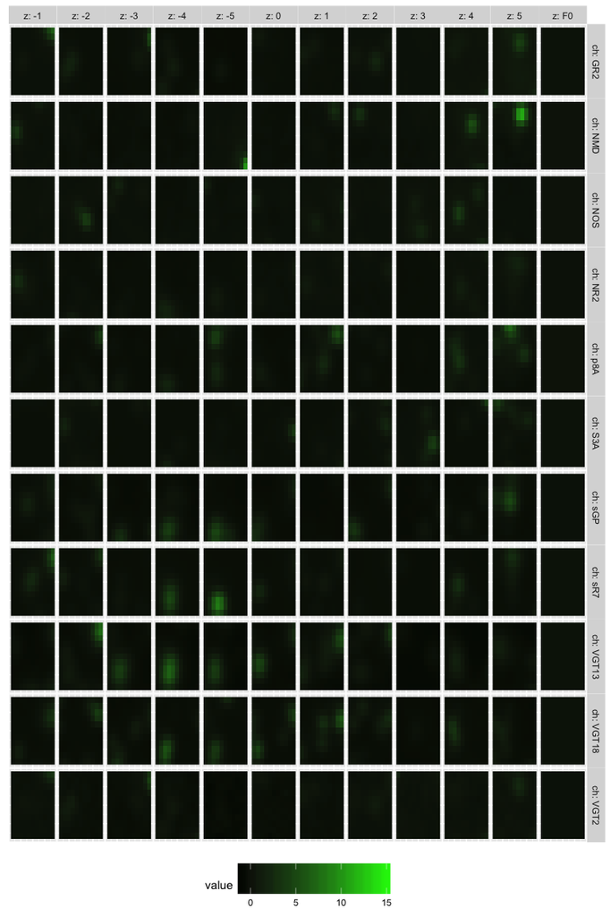

```r
print(abtab)
plot(ggpavgmat[[1]]$pex)
```

## Here I calculate F0 from the raw data and log_10 it :X:

Here I am plotting the Z-scored data in the synaptograms and the log_10 of the F0 value I get from the raw data. Also, no good.

```r
## Calculate feature F0
F0 <-
  foreach(j = 1:dim(datO)[1]) %:%
  foreach(i = 1:dim(datO)[2]) %do% {
      #f0 <- matrix(sum(dat[j,i,,,]), 2*bf +1, 2*bf +1)
      f0 <- log10(sum(datO[j,i,,,]))
}

names(F0) <- 1:length(F0)
for(i in 1:length(F0)){
  names(F0[[i]]) <- cnames
}

rr <- foreach(l = 1:dim(dat)[1]) %do% {
  r <- dat[l,,,,]
  mr <- melt(r)
  names(mr) <- c("ch", "x", "y", "z", "value")
  mr$z <- mr$z - (max(mr$z) +1)/2

  F0z <- Reduce('rbind',
           lapply(names(F0[[l]]),
             function(n){
             Fz <- mr[mr$ch == n,]
             Fz$z <- "F0log10"#as.numeric(max(mr$z)+1)
             Fz$value <- as.numeric(F0[[l]][n])
             Fz
             }))

  mr <- rbind(mr, F0z)
  ch <- mr$ch
  mr$type <- ctype$type[ch]
  mr$ch <- as.factor(abcnames[ch])
  mr
  #ch <- F0z$ch
  #F0z$type <- ctype$type[ch]
  #F0z$ch <- abcnames[ch]
  #F0z
}


names(rr) <- 1:length(rr)


th <- theme(axis.text = element_blank(), axis.ticks = element_blank(),
            axis.title.y = element_blank(), axis.title.x = element_blank(),
            legend.position="bottom", legend.key.size = unit(2,'lines'),
            panel.spacing = unit(0, "lines"))

mmex <- min(sapply(rr, function(am){ min(am[am$type == "ex",]$value) }))
MMex <- max(sapply(rr, function(am){ max(am[am$type == "ex",]$value) }))
mmin <- min(sapply(rr, function(am){ min(am[am$type == "in",]$value) }))
MMin <- max(sapply(rr, function(am){ max(am[am$type == "in",]$value) }))
mmot <- min(sapply(rr, function(am){ min(am[am$type == "ot",]$value) }))
MMot <- max(sapply(rr, function(am){ max(am[am$type == "ot",]$value) }))

ggplogmat <- list()
for(k in 1:length(rr)){
  mr <- rr[[k]]
  pex <-
  ggplot(mr[mr$type == "ex",],
    aes(x,y, group = factor(type), fill = value)) +
    geom_raster() +
    scale_y_reverse() +
    facet_grid(ch ~ z, labeller = label_both) +
    scale_fill_gradient(low = "black", high = "green", limits = c(mmex,MMex)) + th

  pin <-
  ggplot(mr[mr$type == "in",],
    aes(x,y, group = factor(type), fill = value)) +
    geom_raster() +
    scale_y_reverse() +
    facet_grid(ch ~ z, labeller = label_both) +
    scale_fill_gradient(low = "black", high = "red", limits = c(mmin,MMin)) + th

  pot <-
    ggplot(mr[mr$type == "ot",],
    aes(x,y, group = factor(type), fill = value)) +
    geom_raster() +
    scale_y_reverse() +
    facet_grid(ch ~ z, labeller = label_both) +
    scale_fill_gradient(low = "black", high = "blue", limits = c(mmot,MMot)) + th
  #

  lay <- rbind(matrix(1,table(type)['ex'],1),
        matrix(2,table(type)['in'],1),
        matrix(3,table(type)['ot'],1))

  xyzloc = c(x = loc[k,1],
          y = loc[k,2],
          z = loc[k,3])

  p <- arrangeGrob(pex, pin, pot, layout_matrix = lay)

  ggplogmat[[k]] <- list(xyzloc=xyzloc, p=p, pex=pex, pin=pin, pot=pot)
}

save(ggplogmat, file = "F0log10matrix.RData")

mapply(function(grob,locs){
  outName <- paste0("log10matrix",token,
               paste0(c("x", "y", "z"),locs, collapse="_"),
               ".png")
  png(outName,
      height = sum(tab)*1.5, width = dim(dat)[5]*1.5,
      units = "in", res = 300)
  plot(grob)
  dev.off()},
  lapply(ggplogmat, '[[', 2), lapply(ggplogmat, '[[', 1))
```

```
## quartz_off_screen quartz_off_screen quartz_off_screen quartz_off_screen
##                 2                 2                 2                 2
```

## F0 of raw data log_10 transformed

```
##          CR12ndA    GluR22ndA    PV1stA    VAChT4thA    GABARa14thA
## ch_names "CR1_2ndA" "GluR2_2ndA" "PV_1stA" "VAChT_4thA" "GABARa1_4thA"
## abb      "CR1"      "GR2"        "PV1"     "VAC"        "GABAR"
##          VGluT22ndA    tubulin8thA    VGluT31stA    TH5thA
## ch_names "VGluT2_2ndA" "tubulin_8thA" "VGluT3_1stA" "TH_5thA"
## abb      "VGT2"        "t8A"          "VGT3"        "TH5"
##          VGluT13rdA    NR2B9thA    VGluT18thA    synapsinR7thA
## ch_names "VGluT1_3rdA" "NR2B_9thA" "VGluT1_8thA" "synapsinR_7thA"
## abb      "VGT13"       "NR2"       "VGT18"       "sR7"
##          GAD6thA    VGAT5thA    Synpod3rdA    synapsinGP5thA    psd8thA
## ch_names "GAD_6thA" "VGAT_5thA" "Synpod_3rdA" "synapsinGP_5thA" "psd_8thA"
## abb      "GAD"      "VGA"       "S3A"         "sGP"             "p8A"
##          dapi1stA    GABABR13rdA    NMDAR16thA    NOS9thA
## ch_names "dapi_1stA" "GABABR1_3rdA" "NMDAR1_6thA" "NOS_9thA"
## abb      "d1A"       "GABAB"        "NMD"         "NOS"
##          gephyrin1stA
## ch_names "gephyrin_1stA"
## abb      "g1A"
```

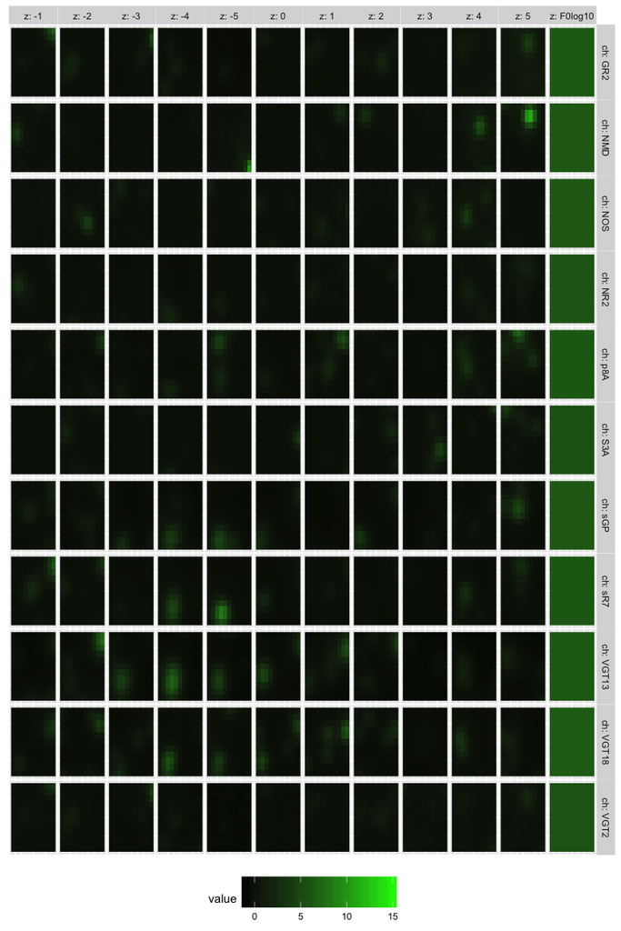

```r
print(abtab)
plot(ggplogmat[[1]]$pex)
```

## Everything squashed to 0-1 :MAYBE?:

Here I am plotting the data squished to 0-1, then I calculate the F0 value on the squished data and then plot F0 squished to 0-1.

```r
## Calculate feature F0
F0 <-
  foreach(j = 1:dim(datS)[1]) %:%
  foreach(i = 1:dim(datS)[2]) %do% {
      #f0 <- matrix(sum(dat[j,i,,,]), 2*bf +1, 2*bf +1)
      f0 <- sum(datS[j,i,,,])
}

F0S <- lapply(F0, function(y){
         x <- as.numeric(y)
         (x - min(x))/(max(x) - min(x))
  })

names(F0S) <- 1:length(F0S)
for(i in 1:length(F0S)){
  names(F0S[[i]]) <- cnames
}

rr <- foreach(l = 1:dim(dat)[1]) %do% {
  r <- datS[l,,,,]
  mr <- melt(r)
  names(mr) <- c("ch", "x", "y", "z", "value")
  mr$z <- mr$z - (max(mr$z) +1)/2

  F0z <- Reduce('rbind',
           lapply(names(F0S[[l]]),
             function(n){
             Fz <- mr[mr$ch == n,]
             Fz$z <- "F0_0-1"#as.numeric(max(mr$z)+1)
             Fz$value <- as.numeric(F0S[[l]][n])
             Fz
             }))

  mr <- rbind(mr, F0z)
  ch <- mr$ch
  mr$type <- ctype$type[ch]
  mr$ch <- as.factor(abcnames[ch])
  mr
  #ch <- F0z$ch
  #F0z$type <- ctype$type[ch]
  #F0z$ch <- abcnames[ch]
  #F0z
}


names(rr) <- 1:length(rr)

th <- theme(axis.text = element_blank(), axis.ticks = element_blank(),
            axis.title.y = element_blank(), axis.title.x = element_blank(),
            legend.position="bottom", legend.key.size = unit(2,'lines'),
            panel.spacing = unit(0, "lines"))

mmex <- 0 #min(sapply(rr, function(am){ min(am[am$type == "ex",]$value) }))
MMex <- 1 #max(sapply(rr, function(am){ max(am[am$type == "ex",]$value) }))
mmin <- 0 #min(sapply(rr, function(am){ min(am[am$type == "in",]$value) }))
MMin <- 1 #max(sapply(rr, function(am){ max(am[am$type == "in",]$value) }))
mmot <- 0 #min(sapply(rr, function(am){ min(am[am$type == "ot",]$value) }))
MMot <- 1 #max(sapply(rr, function(am){ max(am[am$type == "ot",]$value) }))

ggp01mat <- list()
for(k in 1:length(rr)){
  mr <- rr[[k]]
  pex <-
  ggplot(mr[mr$type == "ex",],
    aes(x,y, group = factor(type), fill = value)) +
    geom_raster() +
    scale_y_reverse() +
    facet_grid(ch ~ z, labeller = label_both) +
    scale_fill_gradient(low = "black", high = "green", limits = c(mmex,MMex)) + th

  pin <-
  ggplot(mr[mr$type == "in",],
    aes(x,y, group = factor(type), fill = value)) +
    geom_raster() +
    scale_y_reverse() +
    facet_grid(ch ~ z, labeller = label_both) +
    scale_fill_gradient(low = "black", high = "red", limits = c(mmin,MMin)) + th

  pot <-
    ggplot(mr[mr$type == "ot",],
    aes(x,y, group = factor(type), fill = value)) +
    geom_raster() +
    scale_y_reverse() +
    facet_grid(ch ~ z, labeller = label_both) +
    scale_fill_gradient(low = "black", high = "blue", limits = c(mmot,MMot)) + th
  #

  lay <- rbind(matrix(1,table(type)['ex'],1),
        matrix(2,table(type)['in'],1),
        matrix(3,table(type)['ot'],1))

  xyzloc = c(x = loc[k,1],
          y = loc[k,2],
          z = loc[k,3])

  p <- arrangeGrob(pex, pin, pot, layout_matrix = lay)

  ggp01mat[[k]] <- list(xyzloc=xyzloc, p=p, pex=pex, pin=pin, pot=pot)
}

save(ggp01mat, file = "F0_01matrix.RData")

mapply(function(grob,locs){
  outName <- paste0("matrix01",token,
               paste0(c("x", "y", "z"),locs, collapse="_"),
               ".png")
  png(outName,
      height = sum(tab)*1.5, width = dim(dat)[5]*1.5,
      units = "in", res = 300)
  plot(grob)
  dev.off()},
  lapply(ggp01mat, '[[', 2), lapply(ggp01mat, '[[', 1))
```

```
## quartz_off_screen quartz_off_screen quartz_off_screen quartz_off_screen
##                 2                 2                 2                 2
```

## F0 on 0-1 scaled data, scaled to 0-1

```
##          CR12ndA    GluR22ndA    PV1stA    VAChT4thA    GABARa14thA
## ch_names "CR1_2ndA" "GluR2_2ndA" "PV_1stA" "VAChT_4thA" "GABARa1_4thA"
## abb      "CR1"      "GR2"        "PV1"     "VAC"        "GABAR"
##          VGluT22ndA    tubulin8thA    VGluT31stA    TH5thA
## ch_names "VGluT2_2ndA" "tubulin_8thA" "VGluT3_1stA" "TH_5thA"
## abb      "VGT2"        "t8A"          "VGT3"        "TH5"
##          VGluT13rdA    NR2B9thA    VGluT18thA    synapsinR7thA
## ch_names "VGluT1_3rdA" "NR2B_9thA" "VGluT1_8thA" "synapsinR_7thA"
## abb      "VGT13"       "NR2"       "VGT18"       "sR7"
##          GAD6thA    VGAT5thA    Synpod3rdA    synapsinGP5thA    psd8thA
## ch_names "GAD_6thA" "VGAT_5thA" "Synpod_3rdA" "synapsinGP_5thA" "psd_8thA"
## abb      "GAD"      "VGA"       "S3A"         "sGP"             "p8A"
##          dapi1stA    GABABR13rdA    NMDAR16thA    NOS9thA
## ch_names "dapi_1stA" "GABABR1_3rdA" "NMDAR1_6thA" "NOS_9thA"
## abb      "d1A"       "GABAB"        "NMD"         "NOS"
##          gephyrin1stA
## ch_names "gephyrin_1stA"
## abb      "g1A"
```

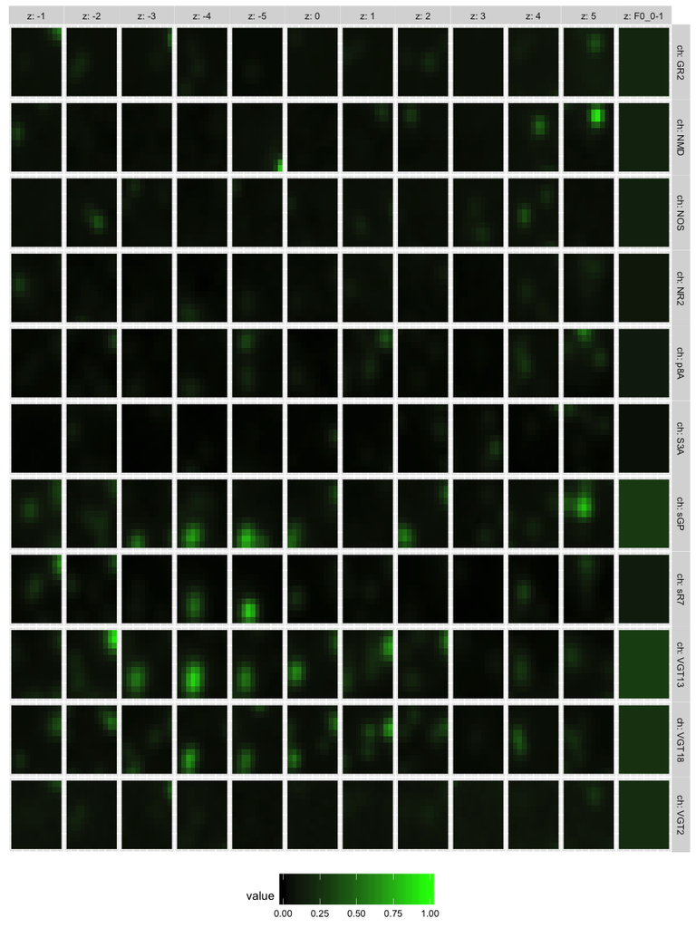

```r
print(abtab)
plot(ggp01mat[[1]]$pex)
```

## F0 as separate column on side :better?:

Here I’m back to the Z-scored data for synaptograms and it’s corresponding F0, where the F0 value is plotted separately adn on it’s own color bar. Seems a bit messy, but better than the above attempts.

```r
## Calculate feature F0
F0 <-
  foreach(j = 1:dim(dat)[1]) %:%
  foreach(i = 1:dim(dat)[2]) %do% {
      f0 <- sum(dat[j,i,,,])
}

names(F0) <- 1:length(F0)
for(i in 1:length(F0)){
  names(F0[[i]]) <- cnames
}


rr <- foreach(l = 1:dim(dat)[1]) %do% {
  r <- dat[l,,,,]
  mr <- melt(r)
  names(mr) <- c("ch", "x", "y", "z", "value")
  mr$z <- mr$z - (max(mr$z) +1)/2

  F0z <- Reduce('rbind',
           lapply(names(F0[[l]]),
             function(n){
             Fz <- mr[mr$ch == n,]
             #Fz$z <- as.numeric(max(mr$z)+1)
             Fz$F0 <- round(as.numeric(F0[[l]][n]),4)
             Fz
             }))

  #mr <- rbind(mr, F0z)
  #ch <- mr$ch
  #mr$type <- ctype$type[ch]
  #mr$ch <- abcnames[ch]
  #mr
  ch <- F0z$ch
  F0z$type <- ctype$type[ch]
  F0z$ch <- abcnames[ch]
  F0z
}


names(rr) <- 1:length(rr)


th <- theme(axis.text = element_blank(), axis.ticks = element_blank(),
            axis.title.y = element_blank(), axis.title.x = element_blank(),
            legend.position="bottom", legend.key.size = unit(2,'lines'),
            panel.spacing = unit(0, "lines"))

mmex <- min(sapply(rr, function(am){ min(am[am$type == "ex",]$value) }))
MMex <- max(sapply(rr, function(am){ max(am[am$type == "ex",]$value) }))
mmin <- min(sapply(rr, function(am){ min(am[am$type == "in",]$value) }))
MMin <- max(sapply(rr, function(am){ max(am[am$type == "in",]$value) }))
mmot <- min(sapply(rr, function(am){ min(am[am$type == "ot",]$value) }))
MMot <- max(sapply(rr, function(am){ max(am[am$type == "ot",]$value) }))

ggpsep <- list()
for(k in 1:length(rr)){
  mr <- rr[[k]]
  pex <-
  ggplot(mr[mr$type == "ex",],
    aes(x,y, group = factor(type), fill = value)) +
    geom_raster() +
    scale_y_reverse() +
    facet_grid(ch + F0 ~ z, labeller = label_both) +
    scale_fill_gradient(low = "black", high = "green", limits = c(mmex,MMex)) + th

  pexF0 <-
    ggplot(mr[mr$type == "ex" ,],
      aes(x,y, group = factor(type), fill = F0)) +
      geom_raster() +
      scale_y_reverse() +
      facet_grid(ch +F0 ~ type, labeller = label_both) +
      scale_fill_gradient(low = "black", high = "white") + th

  pin <-
  ggplot(mr[mr$type == "in",],
    aes(x,y, group = factor(type), fill = value)) +
    geom_raster() +
    scale_y_reverse() +
    facet_grid(ch + F0 ~ z, labeller = label_both) +
    scale_fill_gradient(low = "black", high = "red", limits = c(mmin,MMin)) + th

  pinF0 <-
    ggplot(mr[mr$type == "in" ,],
      aes(x,y, group = factor(type), fill = F0)) +
      geom_raster() +
      scale_y_reverse() +
      facet_grid(ch +F0 ~ type, labeller = label_both) +
      scale_fill_gradient(low = "black", high = "white") + th

  pot <-
    ggplot(mr[mr$type == "ot",],
    aes(x,y, group = factor(type), fill = value)) +
    geom_raster() +
    scale_y_reverse() +
    facet_grid(ch + F0 ~ z, labeller = label_both) +
    scale_fill_gradient(low = "black", high = "blue", limits = c(mmot,MMot)) + th

  potF0 <-
    ggplot(mr[mr$type == "ot" ,],
      aes(x,y, group = factor(type), fill = F0)) +
      geom_raster() +
      scale_y_reverse() +
      facet_grid(ch +F0 ~ type, labeller = label_both) +
      scale_fill_gradient(low = "black", high = "white") + th

  xyzloc = c(x = loc[k,1],
          y = loc[k,2],
          z = loc[k,3])

  lz <- length(range(mr$z)[1]:range(mr$z)[2])

  laysep <- c()
  kj <- 1
  for(i in seq(1,5,2)){
    inner <- c()
    for(j in 1:table(type)[kj]){
      inner <- rbind(inner, c(rep(i, lz),rep(i+1,2)))
    }
  kj <- kj +1
  laysep <- rbind(laysep, inner)
  }

  psep <- arrangeGrob(pex, pexF0, pin, pinF0, pot, potF0, layout_matrix = laysep)

  ggpsep[[k]] <- list(xyzloc=xyzloc, p=psep,
                   pex=pex, pexF0=pexF0,
                   pin=pin, pinF0=pinF0,
                   pot=pot, potF0=potF0)
}

save(ggpsep, file = "F0sep.RData")

mapply(function(grob,locs){
  outName <- paste0("sep",token,
               paste0(c("x", "y", "z"),locs, collapse="_"),
               ".png")
  png(outName,
      height = sum(tab)*1.5, width = (dim(dat)[5]+1)*1.5,
      units = "in", res = 300)
  plot(grob)
  dev.off()},
  lapply(ggpsep, '[[', 2), lapply(ggpsep, '[[', 1))
```

```
## quartz_off_screen quartz_off_screen quartz_off_screen quartz_off_screen
##                 2                 2                 2                 2
```

```
##          CR12ndA    GluR22ndA    PV1stA    VAChT4thA    GABARa14thA
## ch_names "CR1_2ndA" "GluR2_2ndA" "PV_1stA" "VAChT_4thA" "GABARa1_4thA"
## abb      "CR1"      "GR2"        "PV1"     "VAC"        "GABAR"
##          VGluT22ndA    tubulin8thA    VGluT31stA    TH5thA
## ch_names "VGluT2_2ndA" "tubulin_8thA" "VGluT3_1stA" "TH_5thA"
## abb      "VGT2"        "t8A"          "VGT3"        "TH5"
##          VGluT13rdA    NR2B9thA    VGluT18thA    synapsinR7thA
## ch_names "VGluT1_3rdA" "NR2B_9thA" "VGluT1_8thA" "synapsinR_7thA"
## abb      "VGT13"       "NR2"       "VGT18"       "sR7"
##          GAD6thA    VGAT5thA    Synpod3rdA    synapsinGP5thA    psd8thA
## ch_names "GAD_6thA" "VGAT_5thA" "Synpod_3rdA" "synapsinGP_5thA" "psd_8thA"
## abb      "GAD"      "VGA"       "S3A"         "sGP"             "p8A"
##          dapi1stA    GABABR13rdA    NMDAR16thA    NOS9thA
## ch_names "dapi_1stA" "GABABR1_3rdA" "NMDAR1_6thA" "NOS_9thA"
## abb      "d1A"       "GABAB"        "NMD"         "NOS"
##          gephyrin1stA
## ch_names "gephyrin_1stA"
## abb      "g1A"
```

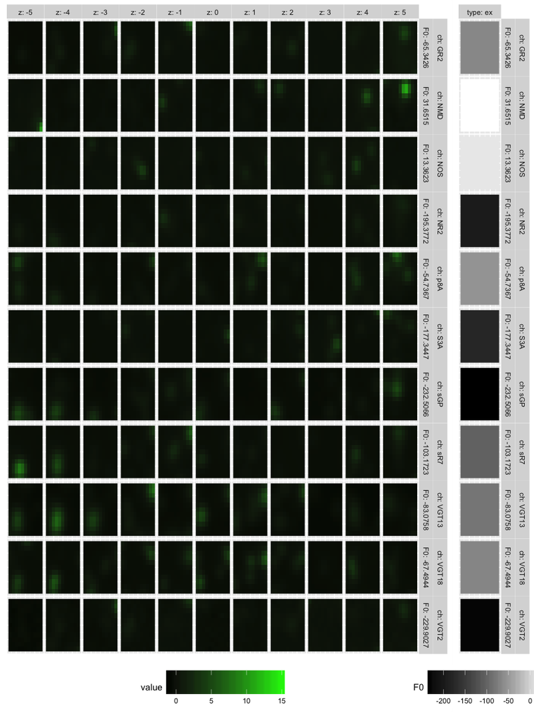

```r
print(abtab)
lnew <- matrix(laysep[1,], nrow =1)
pnew <- arrangeGrob(ggpsep[[1]]$pex, ggpsep[[1]]$pexF0,layout_matrix = lnew)
plot(pnew)
```